# HR Analytics

IBM HR Analytics Employee Attrition & Performance

Ecole Polytechnique CSE204 Machine Learning Final Project

```python
import pandas as pd
import numpy as np
import matplotlib.pyplot as plt
import seaborn as sns
%matplotlib inline
```

**Data Cleaning**

> Data cleaning is one of the biggest challenges in Machine Learning when it comes to use data. It is very critical for the success of ML applications. Even though with a powerful algorithm, ideal results are not secure without the relevant ot right training data. In order to improve the quality of the training data for analytics and enables accurate decision-making we will use Data cleaning that will identify and remove errors and duplicate data.

Data cleaning consists on:

1. Fill-out missing values
2. Removing rows with missing values
3. Fixing errors in the structure
4. Reducing data for proper data handling

```python
df = pd.read_csv('https://raw.githubusercontent.com/makramloughman/HR-Analytics/master/data.csv')
```

```python
# Understanding the data
df.info()
df.head()
```

```
<class 'pandas.core.frame.DataFrame'>
RangeIndex: 1470 entries, 0 to 1469
Data columns (total 35 columns):
 #   Column                    Non-Null Count  Dtype
---  ------                    --------------  -----
 0   Age                       1470 non-null   int64
 1   Attrition                 1470 non-null   object
 2   BusinessTravel            1470 non-null   object
 3   DailyRate                 1470 non-null   int64
 4   Department                1470 non-null   object
 5   DistanceFromHome          1470 non-null   int64
 6   Education                 1470 non-null   int64
 7   EducationField            1470 non-null   object
 8   EmployeeCount             1470 non-null   int64
 9   EmployeeNumber            1470 non-null   int64
```

[output cut: 27 more lines]

|  | Age | Attrition | BusinessTravel | DailyRate | Department | DistanceFromHome | Education | EducationField | EmployeeCount | EmployeeNumber | EnvironmentSatisfaction | Gender | HourlyRate | JobInvolvement | JobLevel | JobRole | JobSatisfaction | MaritalStatus | MonthlyIncome | MonthlyRate | NumCompaniesWorked | Over18 | OverTime | PercentSalaryHike | PerformanceRating | RelationshipSatisfaction | StandardHours | StockOptionLevel | TotalWorkingYears | … |
| --- | --- | --- | --- | --- | --- | --- | --- | --- | --- | --- | --- | --- | --- | --- | --- | --- | --- | --- | --- | --- | --- | --- | --- | --- | --- | --- | --- | --- | --- | --- |
| 0 | 41 | Yes | Travel_Rarely | 1102 | Sales | 1 | 2 | Life Sciences | 1 | 1 | 2 | Female | 94 | 3 | 2 | Sales Executive | 4 | Single | 5993 | 19479 | 8 | Y | Yes | 11 | 3 | 1 | 80 | 0 | 8 | … |
| 1 | 49 | No | Travel_Frequently | 279 | Research & Development | 8 | 1 | Life Sciences | 1 | 2 | 3 | Male | 61 | 2 | 2 | Research Scientist | 2 | Married | 5130 | 24907 | 1 | Y | No | 23 | 4 | 4 | 80 | 1 | 10 | … |
| 2 | 37 | Yes | Travel_Rarely | 1373 | Research & Development | 2 | 2 | Other | 1 | 4 | 4 | Male | 92 | 2 | 1 | Laboratory Technician | 3 | Single | 2090 | 2396 | 6 | Y | Yes | 15 | 3 | 2 | 80 | 0 | 7 | … |
| 3 | 33 | No | Travel_Frequently | 1392 | Research & Development | 3 | 4 | Life Sciences | 1 | 5 | 4 | Female | 56 | 3 | 1 | Research Scientist | 3 | Married | 2909 | 23159 | 1 | Y | Yes | 11 | 3 | 3 | 80 | 0 | 8 | … |
| 4 | 27 | No | Travel_Rarely | 591 | Research & Development | 2 | 1 | Medical | 1 | 7 | 1 | Male | 40 | 3 | 1 | Laboratory Technician | 2 | Married | 3468 | 16632 | 9 | Y | No | 12 | 3 | 4 | 80 | 1 | 6 | … |

```python
# Shape
print(df.shape)
```

```
(1470, 35)
```

```python
# Check for missing values
df.isnull().sum()
```

```
Age                         0
Attrition                   0
BusinessTravel              0
DailyRate                   0
Department                  0
DistanceFromHome            0
Education                   0
EducationField              0
EmployeeCount               0
EmployeeNumber              0
EnvironmentSatisfaction     0
Gender                      0
HourlyRate                  0
JobInvolvement              0
JobLevel                    0
JobRole                     0
JobSatisfaction             0
MaritalStatus               0
MonthlyIncome               0
MonthlyRate                 0
NumCompaniesWorked          0
Over18                      0
OverTime                    0
PercentSalaryHike           0
PerformanceRating           0
RelationshipSatisfaction    0
StandardHours               0
StockOptionLevel            0
TotalWorkingYears           0
TrainingTimesLastYear       0
WorkLifeBalance             0
YearsAtCompany              0
YearsInCurrentRole          0
YearsSinceLastPromotion     0
YearsWithCurrManager        0
dtype: int64
```

```python
# Classifying the columns according to their type
df.columns.to_series().groupby(df.dtypes).groups
```

```
{int64: ['Age', 'DailyRate', 'DistanceFromHome', 'Education', 'EmployeeCount', 'EmployeeNumber', 'EnvironmentSatisfaction', 'HourlyRate', 'JobInvolvement', 'JobLevel', 'JobSatisfaction', 'MonthlyIncome', 'MonthlyRate', 'NumCompaniesWorked', 'PercentSalaryHike', 'PerformanceRating', 'RelationshipSati…
```

```python
# Descriptive statistics
df.describe()
```

|  | Age | DailyRate | DistanceFromHome | Education | EmployeeCount | EmployeeNumber | EnvironmentSatisfaction | HourlyRate | JobInvolvement | JobLevel | JobSatisfaction | MonthlyIncome | MonthlyRate | NumCompaniesWorked | PercentSalaryHike | PerformanceRating | RelationshipSatisfaction | StandardHours | StockOptionLevel | TotalWorkingYears | TrainingTimesLastYear | WorkLifeBalance | YearsAtCompany | YearsInCurrentRole | YearsSinceLastPromotion | YearsWithCurrManager |
| --- | --- | --- | --- | --- | --- | --- | --- | --- | --- | --- | --- | --- | --- | --- | --- | --- | --- | --- | --- | --- | --- | --- | --- | --- | --- | --- |
| count | 1470.000000 | 1470.000000 | 1470.000000 | 1470.000000 | 1470.0 | 1470.000000 | 1470.000000 | 1470.000000 | 1470.000000 | 1470.000000 | 1470.000000 | 1470.000000 | 1470.000000 | 1470.000000 | 1470.000000 | 1470.000000 | 1470.000000 | 1470.0 | 1470.000000 | 1470.000000 | 1470.000000 | 1470.000000 | 1470.000000 | 1470.000000 | 1470.000000 | 1470.000000 |
| mean | 36.923810 | 802.485714 | 9.192517 | 2.912925 | 1.0 | 1024.865306 | 2.721769 | 65.891156 | 2.729932 | 2.063946 | 2.728571 | 6502.931293 | 14313.103401 | 2.693197 | 15.209524 | 3.153741 | 2.712245 | 80.0 | 0.793878 | 11.279592 | 2.799320 | 2.761224 | 7.008163 | 4.229252 | 2.187755 | 4.123129 |
| std | 9.135373 | 403.509100 | 8.106864 | 1.024165 | 0.0 | 602.024335 | 1.093082 | 20.329428 | 0.711561 | 1.106940 | 1.102846 | 4707.956783 | 7117.786044 | 2.498009 | 3.659938 | 0.360824 | 1.081209 | 0.0 | 0.852077 | 7.780782 | 1.289271 | 0.706476 | 6.126525 | 3.623137 | 3.222430 | 3.568136 |
| min | 18.000000 | 102.000000 | 1.000000 | 1.000000 | 1.0 | 1.000000 | 1.000000 | 30.000000 | 1.000000 | 1.000000 | 1.000000 | 1009.000000 | 2094.000000 | 0.000000 | 11.000000 | 3.000000 | 1.000000 | 80.0 | 0.000000 | 0.000000 | 0.000000 | 1.000000 | 0.000000 | 0.000000 | 0.000000 | 0.000000 |
| 25% | 30.000000 | 465.000000 | 2.000000 | 2.000000 | 1.0 | 491.250000 | 2.000000 | 48.000000 | 2.000000 | 1.000000 | 2.000000 | 2911.000000 | 8047.000000 | 1.000000 | 12.000000 | 3.000000 | 2.000000 | 80.0 | 0.000000 | 6.000000 | 2.000000 | 2.000000 | 3.000000 | 2.000000 | 0.000000 | 2.000000 |
| 50% | 36.000000 | 802.000000 | 7.000000 | 3.000000 | 1.0 | 1020.500000 | 3.000000 | 66.000000 | 3.000000 | 2.000000 | 3.000000 | 4919.000000 | 14235.500000 | 2.000000 | 14.000000 | 3.000000 | 3.000000 | 80.0 | 1.000000 | 10.000000 | 3.000000 | 3.000000 | 5.000000 | 3.000000 | 1.000000 | 3.000000 |
| 75% | 43.000000 | 1157.000000 | 14.000000 | 4.000000 | 1.0 | 1555.750000 | 4.000000 | 83.750000 | 3.000000 | 3.000000 | 4.000000 | 8379.000000 | 20461.500000 | 4.000000 | 18.000000 | 3.000000 | 4.000000 | 80.0 | 1.000000 | 15.000000 | 3.000000 | 3.000000 | 9.000000 | 7.000000 | 3.000000 | 7.000000 |
| max | 60.000000 | 1499.000000 | 29.000000 | 5.000000 | 1.0 | 2068.000000 | 4.000000 | 100.000000 | 4.000000 | 5.000000 | 4.000000 | 19999.000000 | 26999.000000 | 9.000000 | 25.000000 | 4.000000 | 4.000000 | 80.0 | 3.000000 | 40.000000 | 6.000000 | 4.000000 | 40.000000 | 18.000000 | 15.000000 | 17.000000 |

Unecessary Data:

> All the data feeding into the model should serve the purpose of the project. That is why we should get rid of the unecessary data because it's either informative or irrelevant. From the "describe" function we can already notice that there are two columns with one single value . We will use the code below to specify the features with over 95% rows being the same value.

```python
# Inspect useless features
df.nunique().sort_values()
```

```
Over18                         1
StandardHours                  1
EmployeeCount                  1
Gender                         2
Attrition                      2
PerformanceRating              2
OverTime                       2
MaritalStatus                  3
Department                     3
BusinessTravel                 3
StockOptionLevel               4
EnvironmentSatisfaction        4
JobInvolvement                 4
JobSatisfaction                4
RelationshipSatisfaction       4
WorkLifeBalance                4
Education                      5
JobLevel                       5
EducationField                 6
TrainingTimesLastYear          7
JobRole                        9
NumCompaniesWorked            10
PercentSalaryHike             15
YearsSinceLastPromotion       16
YearsWithCurrManager          18
YearsInCurrentRole            19
DistanceFromHome              29
YearsAtCompany                37
TotalWorkingYears             40
Age                           43
HourlyRate                    71
DailyRate                    886
MonthlyIncome               1349
MonthlyRate                 1427
EmployeeNumber              1470
dtype: int64
```

```python
# Dropping the unecessary data
df.drop(columns=['EmployeeNumber', 'EmployeeCount', 'Over18', 'StandardHours'], inplace=True)
```

**Data Understanding and Visualizing**

> We will start with univariate analysis which is the simplest form of data analysis. Since it's a single variable it doesn’t deal with causes or relationships.

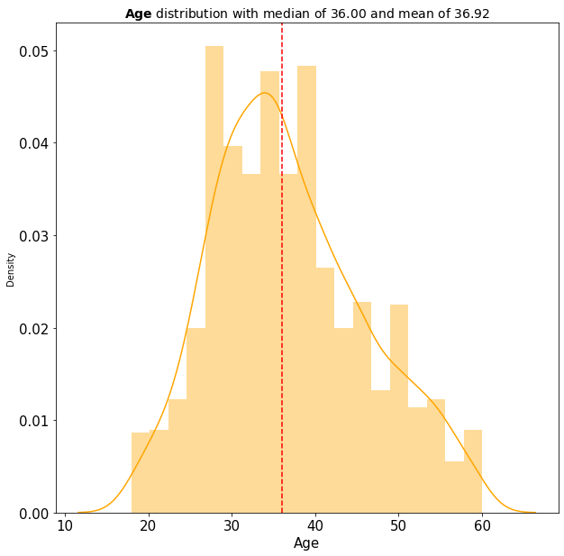

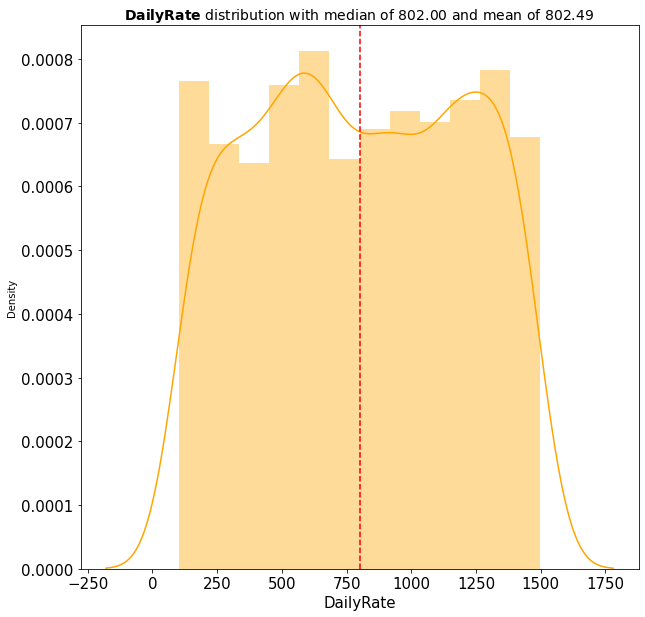

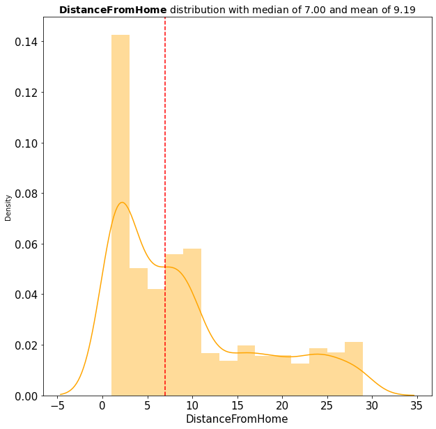

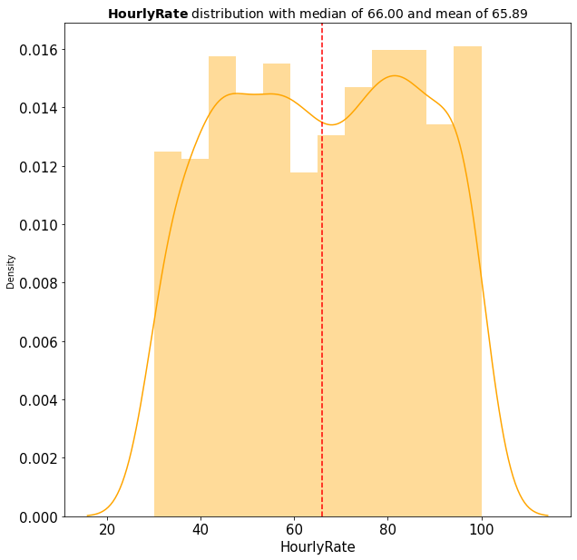

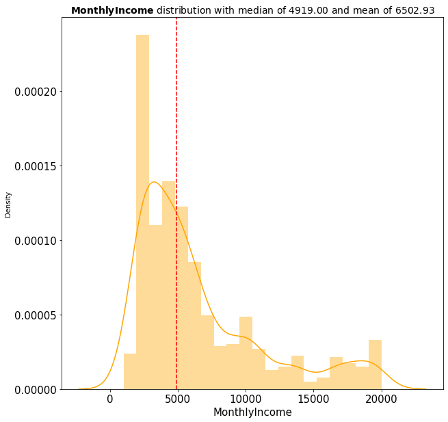

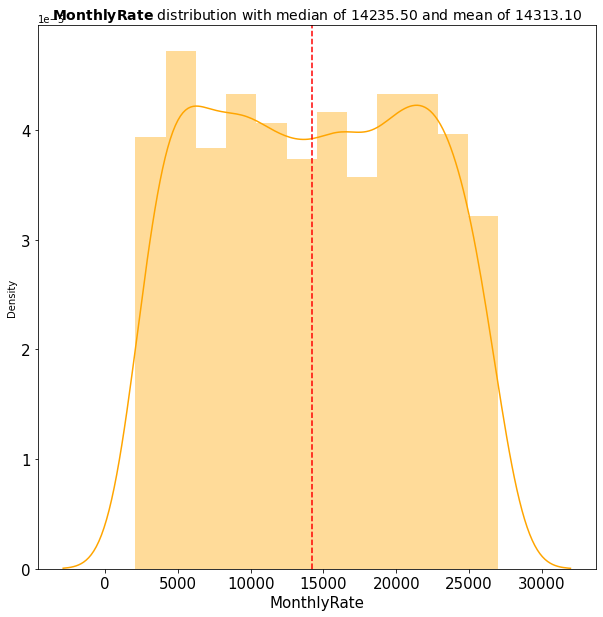

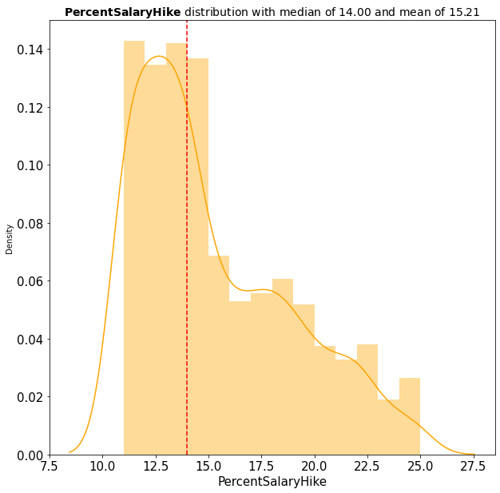

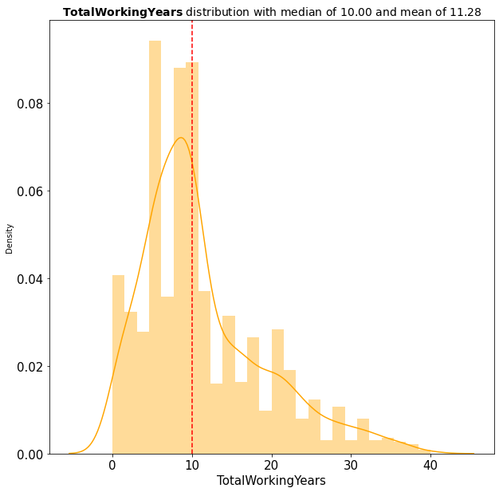

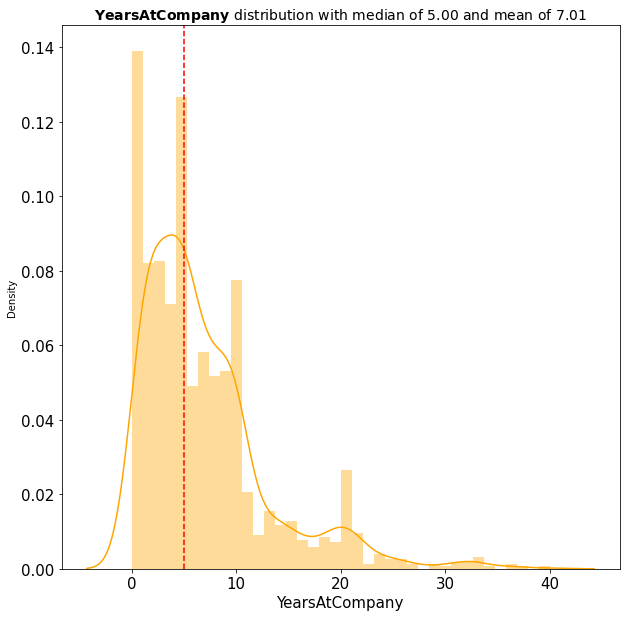

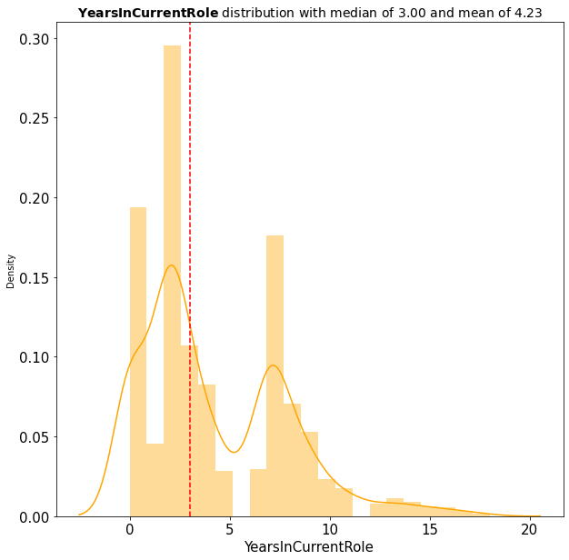

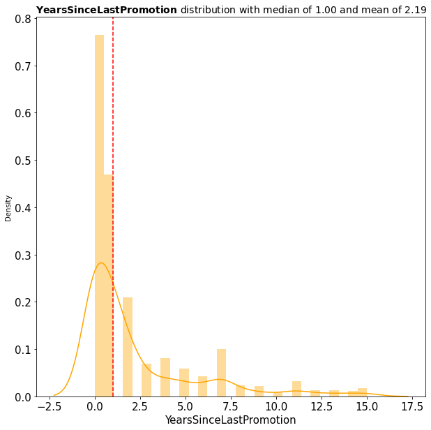

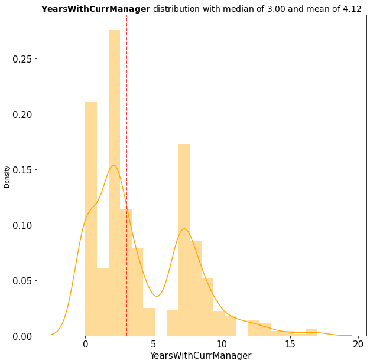

```python
# Get  columns whose data type is int
filteredColumns = df.dtypes[df.dtypes == np.int64]
listOfColumnNames = list(filteredColumns.index)

for i  in listOfColumnNames:
    if len(df[i].unique()) >  10 :

      plt.figure(figsize=(10, 10))
      sns.distplot(df.loc[:, i], kde=True , color = 'orange')
      plt.title(r'$\bf{%s}$ distribution with median of %.2f and mean of %.2f' % \
              (i, np.median(df.loc[:, i]), df.loc[:, i].mean()),
              size=14)
      plt.xlabel(i, fontsize=15)
      plt.xticks(fontsize=15)
      plt.yticks(fontsize=15)
      plt.axvline(np.median(df.loc[:, i]), 0, linestyle='--',
                linewidth=1.5, color='r')
      plt.show()
```

> There are $1470$ employees and $16 \%$ of them left the company. Half of the workers are below $36$ years old, with an average age of $36.92$. More than $50\%$ the workers live nearby the company, with an average distance of $9.19$ Km. The monthly income spans $1,000 \ \$$ to $20,000 \ \$$. Half of the workers earn less than $5,000 \ \$$, and the rest is spread out more evenely between $5,000 \ \$$ and $20,000 \ \$$. Most of the workers have worked $10$ years or less, with a maximum of $40$ years and a mean of $11.28$. More specifically, most of the workers have worked less than $10$ years at the company, with a median of $5$ years and an average of $7.01$ years. In avergae, workers stay in the same position for $4.23$ years, with $50\%$ of them changing in less than $3$ years.

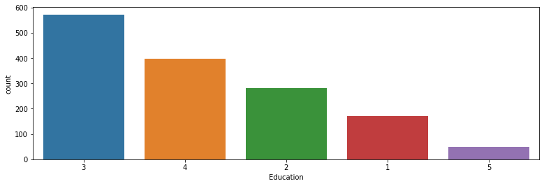

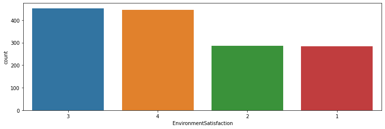

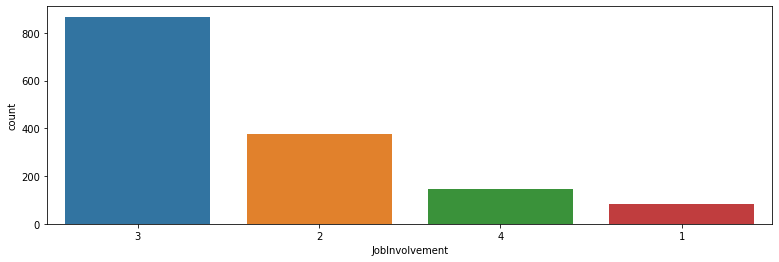

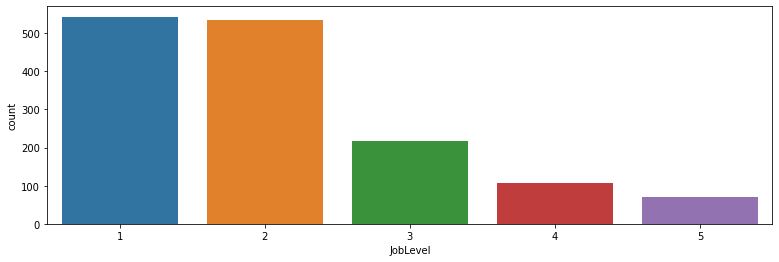

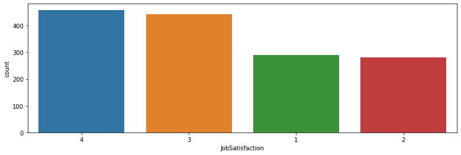

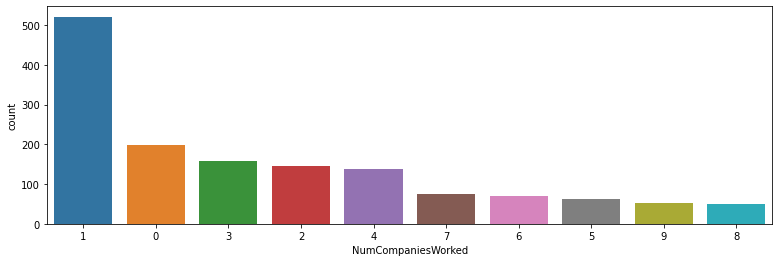

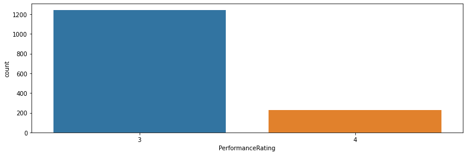

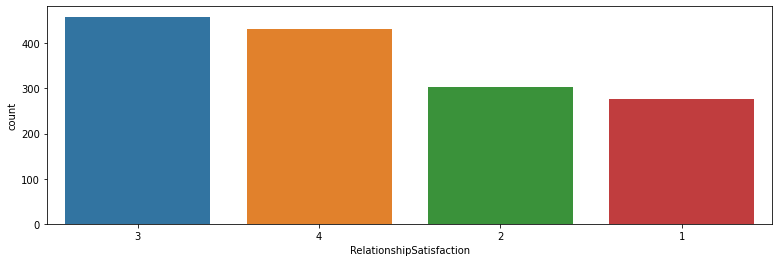

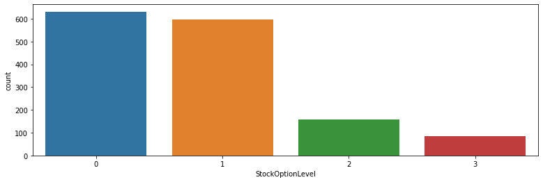

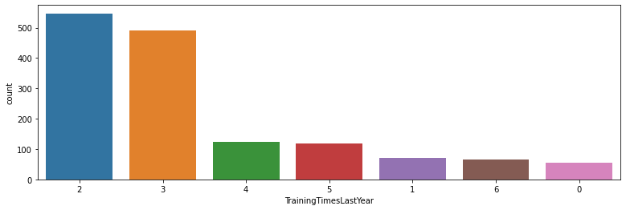

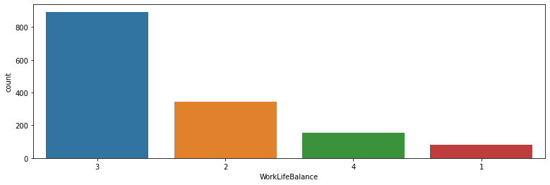

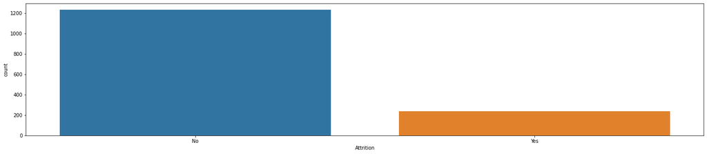

[7 more figures not shown]

```python
for i  in listOfColumnNames:
    if len(df[i].unique()) <=  10:
      plt.figure(figsize=(13, 4))
      sns.countplot(df.loc[:,i].dropna(), order = df.loc[:,i].value_counts().index)

# Get  columns whose data type is object
filteredColumns_obj = df.dtypes[df.dtypes == np.object]
listOfColumnNames_obj = list(filteredColumns_obj.index)
for i  in listOfColumnNames_obj:
      plt.figure(figsize=(25, 5))
      sns.countplot(df.loc[:,i].dropna(), order = df.loc[:,i].value_counts().index)
```

**Comment**

> Most of the workers graduated with a bachelor's degree. Some hold a master's degree, and very few have a PhD. There is also a group of wokers who haven't attended college nor high school. Most of the workers with an educational background studied life sciences or medicine. We also see that 66% of the wokers are satified with the environment, and a notable 33% aren't. The job stafiaction level is not perfect, 33% aren't satisfied. Despite the negative feedback, most of them are well involved. The job roles with highest number of positions are Sales Executive, Laboratory Technician, and Research Scientist. A small but noticebale amount of workers work overtime. Saying this, most workers have a decent work life balance, while a few are struglling to find a balance. Regarding their social satuses, around half are single while the other half is shared by married and divorced workers. On a final note, there are more males than females in the company.

**Multivariable Analysis**

> Multivariate analysis is concerned with the interrelationships among several variables. This kind of analysis is more interesting as it illustrates the relationships among the various characteristics. The aim of the project is to predict employee attrition that is why we will be using multivariable analysis to understand the influence of the various factors on the predicted variable.

Now we will try to understand why employees are leaving the company.

```python
df2 = df.copy()
df2['Attrition'] = df2['Attrition'].apply(lambda x: 0 if x == 'No' else 1)
```

```python
def graph_df(x, y = 'bar', z = 0):
    feature = df2.groupby(x).agg({'Attrition':['size', 'sum', 'mean']})
    feature.columns = [' '.join(col).strip() for col in feature.columns.values]
    feature = feature.reset_index()
    feature['Attrition mean'] = feature['Attrition mean']*100
    feature.columns = [x, 'Total Employee', 'Attrition Number', '% of Attrition in the Relevant Group']
    feature['% of Attrition in the Company'] = (feature['Attrition Number'] / 237) * 100

    fig, ax1 = plt.subplots()
    ax2 = ax1.twinx()
    feature.set_index(feature[x], drop=True, inplace=True)
    feature['Total Employee'].plot(kind = y, stacked = True, ax = ax1, colormap = 'summer', rot = z)
    feature['% of Attrition in the Relevant Group'].plot(use_index = False, kind = 'line', ax = ax2, colormap='Spectral')
    plt.title('Attrition compared to ' + x  + ' Groups', size=16)
    ax1.set_xlabel(x, size=14)
    ax1.yaxis.label.set_color('blue')
    ax1.set_ylabel("Total Employee", size=14)
    ax2.set_ylabel("Attrition Percentage in the Relevant Group", size=14)
    ax2.yaxis.label.set_color('red')
    zoom = 1.5
    w, h = fig.get_size_inches()
    fig.set_size_inches(w * zoom, h * zoom)
    plt.tight_layout()
    plt.show()
    return feature
```

**Age Group**

Which age group is most likely to leave the company?

```python
bins = [17, 21, 25, 35, 60]
group_names = ['(18-21)', '(22-25)', '(26-35)', '(36-60)']
df2['Age'] = pd.cut(df2['Age'], bins, labels = group_names)
```

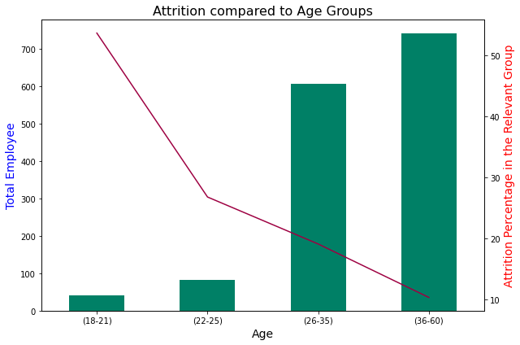

| Age | Age | Total Employee | Attrition Number | % of Attrition in the Relevant Group | % of Attrition in the Company |
| --- | --- | --- | --- | --- | --- |
| (18-21) | (18-21) | 41 | 22 | 53.658537 | 9.282700 |
| (22-25) | (22-25) | 82 | 22 | 26.829268 | 9.282700 |
| (26-35) | (26-35) | 606 | 116 | 19.141914 | 48.945148 |
| (36-60) | (36-60) | 741 | 77 | 10.391363 | 32.489451 |

```python
graph_df(x = 'Age')
```

> It seems to be likely that people in the group age (18-21) leave the company because their attrition proportion to their age group is 53.63%. However, they make up only 9 percent of total attrition. In contrast with people of the group age (26-35) who has the highest percentage of attrition in the company with almost 50%.

**Business Travel**

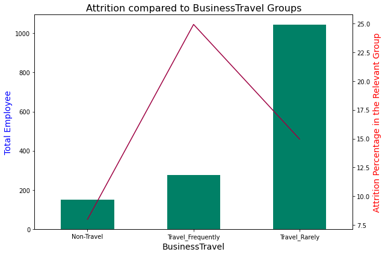

| BusinessTravel | BusinessTravel | Total Employee | Attrition Number | % of Attrition in the Relevant Group | % of Attrition in the Company |
| --- | --- | --- | --- | --- | --- |
| Non-Travel | Non-Travel | 150 | 12 | 8.000000 | 5.063291 |
| Travel_Frequently | Travel_Frequently | 277 | 69 | 24.909747 | 29.113924 |
| Travel_Rarely | Travel_Rarely | 1043 | 156 | 14.956855 | 65.822785 |

```python
graph_df(x = 'BusinessTravel')
```

> Traveling seems to be a cause for workers to quit their jobs. Wee see that the percentage of attrition for workers who travel frequently is the highest. But it represents only 29% of the attrition in the company, which is due to the fact that the number of workers who travel frequently is low in comparision with the number of workers who travel rarely. These have a percentage of attrition of 15%, but they represent 65% of the attrition in the company. Tu sum up, traveling is more likely to cause a worker to leave the company.

**Department**

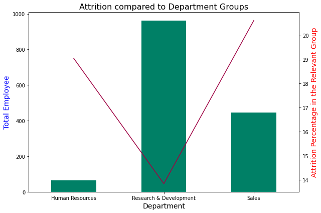

| Department | Department | Total Employee | Attrition Number | % of Attrition in the Relevant Group | % of Attrition in the Company |
| --- | --- | --- | --- | --- | --- |
| Human Resources | Human Resources | 63 | 12 | 19.047619 | 5.063291 |
| Research & Development | Research & Development | 961 | 133 | 13.839750 | 56.118143 |
| Sales | Sales | 446 | 92 | 20.627803 | 38.818565 |

```python
graph_df(x = 'Department')
```

> The results here are interesting. The highest percentage of attrition in the company is found in the research and development department, which has the lowest percentage of attrition amoung the different groups. This can be explained by the highest number of wokers in this department. Otherwise, we see that the human resources and sales deparetment have the highest percentage of attrition amoung groups, with 19% and 20% respectively. To sum up, a worker in human resources and sales is more likely to leave than a worker in research and development.

**Distance From Home**

```python
bins = [0, 3, 6, 10, 29]
group_names = ['1-3', '4-6', '7-10', '10+']
df2['DistanceFromHome'] = pd.cut(df2['DistanceFromHome'], bins, labels = group_names)
```

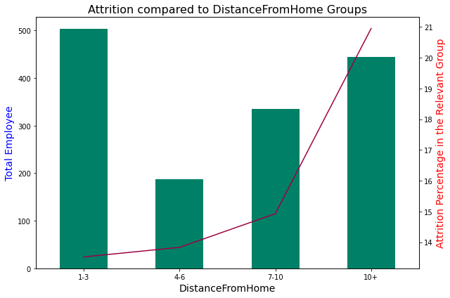

| DistanceFromHome | DistanceFromHome | Total Employee | Attrition Number | % of Attrition in the Relevant Group | % of Attrition in the Company |
| --- | --- | --- | --- | --- | --- |
| 1-3 | 1-3 | 503 | 68 | 13.518887 | 28.691983 |
| 4-6 | 4-6 | 188 | 26 | 13.829787 | 10.970464 |
| 7-10 | 7-10 | 335 | 50 | 14.925373 | 21.097046 |
| 10+ | 10+ | 444 | 93 | 20.945946 | 39.240506 |

```python
graph_df(x = 'DistanceFromHome')
```

> The results seen here are obvious, as living far from work is more likely to make you quit your job to find one closer.

**Education**

Which degree is more affected by employee attrition ?

```python
df2['Education'] = df2['Education'].map({1:'Below College', 2:'College', 3:'Bachelor', 4:'Master', 5:'Doctor'})
```

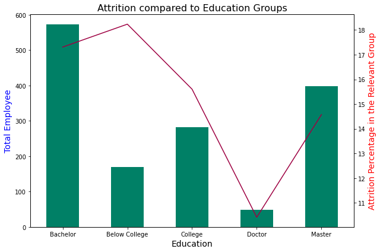

| Education | Education | Total Employee | Attrition Number | % of Attrition in the Relevant Group | % of Attrition in the Company |
| --- | --- | --- | --- | --- | --- |
| Bachelor | Bachelor | 572 | 99 | 17.307692 | 41.772152 |
| Below College | Below College | 170 | 31 | 18.235294 | 13.080169 |
| College | College | 282 | 44 | 15.602837 | 18.565401 |
| Doctor | Doctor | 48 | 5 | 10.416667 | 2.109705 |
| Master | Master | 398 | 58 | 14.572864 | 24.472574 |

```python
graph_df(x = 'Education')
```

> People with a bachelor degree are more affected by employee departure as they have the most attrition percentage in the company, approximately 41,77%. In contrast, People owning a doctor degree make up only 2,1% of total attrition and also have the lowest percentage of attrition in their group.

**Education Field**

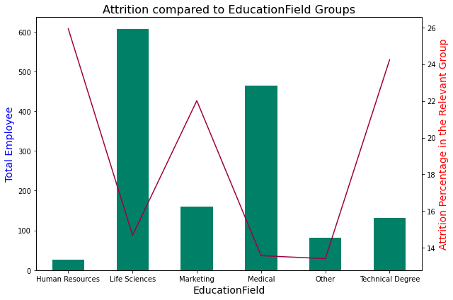

| EducationField | EducationField | Total Employee | Attrition Number | % of Attrition in the Relevant Group | % of Attrition in the Company |
| --- | --- | --- | --- | --- | --- |
| Human Resources | Human Resources | 27 | 7 | 25.925926 | 2.953586 |
| Life Sciences | Life Sciences | 606 | 89 | 14.686469 | 37.552743 |
| Marketing | Marketing | 159 | 35 | 22.012579 | 14.767932 |
| Medical | Medical | 464 | 63 | 13.577586 | 26.582278 |
| Other | Other | 82 | 11 | 13.414634 | 4.641350 |
| Technical Degree | Technical Degree | 132 | 32 | 24.242424 | 13.502110 |

```python
graph_df(x = 'EducationField')
```

> Workers with a HR, marketing, or technical degree are more likely to quit their jobs with a percentage of roughly 25% in each group, in contrast to the remaing groups with an attrition rate of roughly 13% in each group.

**Environment Satisfaction**

Can a positive working environment influence employee to stay?

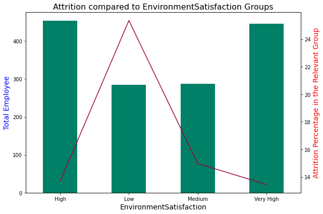

| EnvironmentSatisfaction | EnvironmentSatisfaction | Total Employee | Attrition Number | % of Attrition in the Relevant Group | % of Attrition in the Company |
| --- | --- | --- | --- | --- | --- |
| High | High | 453 | 62 | 13.686534 | 26.160338 |
| Low | Low | 284 | 72 | 25.352113 | 30.379747 |
| Medium | Medium | 287 | 43 | 14.982578 | 18.143460 |
| Very High | Very High | 446 | 60 | 13.452915 | 25.316456 |

```python
df2['EnvironmentSatisfaction'] = df2['EnvironmentSatisfaction'].map({1:'Low', 2:'Medium',
                                                                     3:'High', 4:'Very High'})
graph_df(x = 'EnvironmentSatisfaction')
```

> It is clear from the plot above that there is a negative relationship between Environement satisfaction and turnover intention. In a low environment stasifaction, the attrition percentage is 25% in contrast to the remaining environment staisfaction groups with an attrition percentage of 14% roughly. The percentage of attrition in the company is relative to the group size.

**Gender**

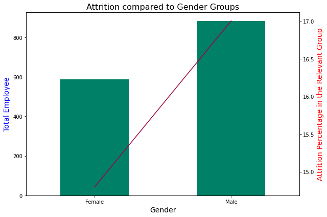

| Gender | Gender | Total Employee | Attrition Number | % of Attrition in the Relevant Group | % of Attrition in the Company |
| --- | --- | --- | --- | --- | --- |
| Female | Female | 588 | 87 | 14.795918 | 36.708861 |
| Male | Male | 882 | 150 | 17.006803 | 63.291139 |

```python
graph_df(x = 'Gender')
```

> We notice that the percentage of attrition per gender is quite similar, even though it is slightly higher for males. But the the percentage of attrition in the company is higher for males, which can be explained by the fact that they outnumber females.